# EDA

### Import Dependencies

```python
# import dependencies
import pandas as pd
import numpy as np
import time
import matplotlib.pyplot as plt
from sklearn import model_selection,svm,ensemble,gaussian_process,linear_model,naive_bayes,neighbors,tree,discriminant_analysis
from sklearn.preprocessing import OneHotEncoder,LabelEncoder,StandardScaler
from sklearn import metrics
import tensorflow as tf

# shows plots in Jupyter Notebook browser
% matplotlib inline

#Common Model Algorithms
# from sklearn import svm, tree, linear_model, neighbors, naive_bayes, ensemble, discriminant_analysis, gaussian_process
# from xgboost import XGBClassifier

#Common Model Helpers
# from sklearn.preprocessing import OneHotEncoder, LabelEncoder
# from sklearn import feature_selection
# from sklearn import model_selection
# from sklearn import metrics

#Visualization
# import matplotlib as mpl
# import matplotlib.pyplot as plt
# import matplotlib.pylab as pylab
# import seaborn as sns
# from pandas.tools.plotting import scatter_matrix
```

### Load Data

```python
# read csv data files
data_train_raw = pd.read_csv('./dataset/train.csv')
data_test_raw = pd.read_csv('./dataset/test.csv')
data_submission = pd.read_csv('./dataset/gender_submission.csv')

# display training dataset
data_train_raw.head()
```

|  | PassengerId | Survived | Pclass | Name | Sex | Age | SibSp | Parch | Ticket | Fare | Cabin | Embarked |
| --- | --- | --- | --- | --- | --- | --- | --- | --- | --- | --- | --- | --- |
| 0 | 1 | 0 | 3 | Braund, Mr. Owen Harris | male | 22.0 | 1 | 0 | A/5 21171 | 7.2500 | NaN | S |
| 1 | 2 | 1 | 1 | Cumings, Mrs. John Bradley (Florence Briggs Th... | female | 38.0 | 1 | 0 | PC 17599 | 71.2833 | C85 | C |
| 2 | 3 | 1 | 3 | Heikkinen, Miss. Laina | female | 26.0 | 0 | 0 | STON/O2. 3101282 | 7.9250 | NaN | S |
| 3 | 4 | 1 | 1 | Futrelle, Mrs. Jacques Heath (Lily May Peel) | female | 35.0 | 1 | 0 | 113803 | 53.1000 | C123 | S |
| 4 | 5 | 0 | 3 | Allen, Mr. William Henry | male | 35.0 | 0 | 0 | 373450 | 8.0500 | NaN | S |

### Display Feature Info

The raw dataset is far from perfect. As we can see, the Age, Cabin, and Embarked features have missing values.

```python
data_train_raw.info()
```

```
<class 'pandas.core.frame.DataFrame'>
RangeIndex: 891 entries, 0 to 890
Data columns (total 12 columns):
PassengerId    891 non-null int64
Survived       891 non-null int64
Pclass         891 non-null int64
Name           891 non-null object
Sex            891 non-null object
Age            714 non-null float64
SibSp          891 non-null int64
Parch          891 non-null int64
Ticket         891 non-null object
Fare           891 non-null float64
Cabin          204 non-null object
Embarked       889 non-null object
dtypes: float64(2), int64(5), object(5)
memory usage: 83.6+ KB
```

### Drop Non-Value Added Column Features

Since the Cabin feature has a significant number of null values, we decide to exclude this feature from our analysis by dropping the column. In addition, we don't need the PassengerId or Ticket number since neither have an impact on our 'Survived' outcome variable.

```python
df = data_train_raw.copy() # create a copy of the raw dataframe
df.drop(['PassengerId','Cabin','Ticket'],axis=1,inplace=True) # drop two columns
df.isna().sum() # display top of dataframe
```

```
Survived      0
Pclass        0
Name          0
Sex           0
Age         177
SibSp         0
Parch         0
Fare          0
Embarked      2
dtype: int64
```

### Impute Missing Values in Dataset

The Age and Embarked features have 177 and 2 missing values respectively. We don't want to drop 177 training examples from our dataset, so we'll impute the missing Age values with the median. We'll impute the 2 missing Embarked values with its mode.

```python
df.Age.fillna(df.Age.median(),inplace=True) # fill in with the median age (in this case, 28.0)
df.Embarked.fillna(df.Embarked.mode()[0],inplace=True) # fill in with the most common embarkment location
df.isna().sum() # check to see if there are anymore na's
```

```
Survived    0
Pclass      0
Name        0
Sex         0
Age         0
SibSp       0
Parch       0
Fare        0
Embarked    0
dtype: int64
```

### Feature Engineering

```python
df['Title'] = df.Name.str.split(', ',expand=True)[1].str.split('.',expand=True)[0] # retrieve persons title from the Name column
df['FamilySize'] = df.SibSp + df.Parch + 1 # calculate family size by summing up the number of Siblings/Spouses and Parents/Children on board, plus the individual themselves
df['IsAlone'] = 0 # create new IsAlone column and set to zero
df.IsAlone[df.FamilySize == 1] = 1 # if family size is 1, this individual is on the ship by themselves
df['FareBin'] = pd.qcut(df.Fare,4) # pandas segregates the Fare feature into 4 evenly split quartiles
df['AgeBin'] = pd.cut(df.Age.astype(int),5) # pandas segregates the Age feature into 5 evenly split age groups
df.Title.value_counts()
```

```
Mr              517
Miss            182
Mrs             125
Master           40
Dr                7
Rev               6
Col               2
Major             2
Mlle              2
Don               1
Jonkheer          1
Mme               1
Ms                1
the Countess      1
Lady              1
Capt              1
Sir               1
Name: Title, dtype: int64
```

```python
# group Titles that have less than 10 instances as 'Misc'
title_check = df.Title.value_counts() < 10
df.Title = df.Title.apply(lambda x: 'Misc' if title_check[x] == True else x)
df.Title.value_counts()
```

```
Mr        517
Miss      182
Mrs       125
Master     40
Misc       27
Name: Title, dtype: int64
```

### Encode Categorical Features

```python
label = LabelEncoder()
df['Sex_Code'] = label.fit_transform(df.Sex)
df['Embarked_Code'] = label.fit_transform(df.Embarked)
df['Title_Code'] = label.fit_transform(df.Title)
df['Fare_Code'] = label.fit_transform(df.FareBin)
df['Age_Code'] = label.fit_transform(df.AgeBin)
df.head()
```

|  | Survived | Pclass | Name | Sex | Age | SibSp | Parch | Fare | Embarked | Title | FamilySize | IsAlone | FareBin | AgeBin | Sex_Code | Embarked_Code | Title_Code | Fare_Code | Age_Code |
| --- | --- | --- | --- | --- | --- | --- | --- | --- | --- | --- | --- | --- | --- | --- | --- | --- | --- | --- | --- |
| 0 | 0 | 3 | Braund, Mr. Owen Harris | male | 22.0 | 1 | 0 | 7.2500 | S | Mr | 2 | 0 | (-0.001, 7.91] | (16.0, 32.0] | 1 | 2 | 3 | 0 | 1 |
| 1 | 1 | 1 | Cumings, Mrs. John Bradley (Florence Briggs Th... | female | 38.0 | 1 | 0 | 71.2833 | C | Mrs | 2 | 0 | (31.0, 512.329] | (32.0, 48.0] | 0 | 0 | 4 | 3 | 2 |
| 2 | 1 | 3 | Heikkinen, Miss. Laina | female | 26.0 | 0 | 0 | 7.9250 | S | Miss | 1 | 1 | (7.91, 14.454] | (16.0, 32.0] | 0 | 2 | 2 | 1 | 1 |
| 3 | 1 | 1 | Futrelle, Mrs. Jacques Heath (Lily May Peel) | female | 35.0 | 1 | 0 | 53.1000 | S | Mrs | 2 | 0 | (31.0, 512.329] | (32.0, 48.0] | 0 | 2 | 4 | 3 | 2 |
| 4 | 0 | 3 | Allen, Mr. William Henry | male | 35.0 | 0 | 0 | 8.0500 | S | Mr | 1 | 1 | (7.91, 14.454] | (32.0, 48.0] | 1 | 2 | 3 | 1 | 2 |

### Remove Redundant Features

```python
# drop irrelvant and redundant feature columns
df_numerical = df.drop(labels=['Name','Sex','Title','Age','Embarked','Fare','FareBin','AgeBin'],axis=1).copy()
df_numerical.head()
```

|  | Survived | Pclass | SibSp | Parch | FamilySize | IsAlone | Sex_Code | Embarked_Code | Title_Code | Fare_Code | Age_Code |
| --- | --- | --- | --- | --- | --- | --- | --- | --- | --- | --- | --- |
| 0 | 0 | 3 | 1 | 0 | 2 | 0 | 1 | 2 | 3 | 0 | 1 |
| 1 | 1 | 1 | 1 | 0 | 2 | 0 | 0 | 0 | 4 | 3 | 2 |
| 2 | 1 | 3 | 0 | 0 | 1 | 1 | 0 | 2 | 2 | 1 | 1 |
| 3 | 1 | 1 | 1 | 0 | 2 | 0 | 0 | 2 | 4 | 3 | 2 |
| 4 | 0 | 3 | 0 | 0 | 1 | 1 | 1 | 2 | 3 | 1 | 2 |

### Compute Correlation Matrix

```python
# compute correlation matrix
corr = df_numerical.corr()
corr
```

|  | Survived | Pclass | SibSp | Parch | FamilySize | IsAlone | Sex_Code | Embarked_Code | Title_Code | Fare_Code | Age_Code |
| --- | --- | --- | --- | --- | --- | --- | --- | --- | --- | --- | --- |
| Survived | 1.000000 | -0.338481 | -0.035322 | 0.081629 | 0.016639 | -0.203367 | -0.543351 | -0.167675 | -0.083292 | 0.299357 | -0.044492 |
| Pclass | -0.338481 | 1.000000 | 0.083081 | 0.018443 | 0.065997 | 0.135207 | 0.131900 | 0.162098 | -0.035538 | -0.634271 | -0.358005 |
| SibSp | -0.035322 | 0.083081 | 1.000000 | 0.414838 | 0.890712 | -0.584471 | -0.114631 | 0.068230 | -0.243463 | 0.393025 | -0.218846 |
| Parch | 0.081629 | 0.018443 | 0.414838 | 1.000000 | 0.783111 | -0.583398 | -0.245489 | 0.039798 | -0.119511 | 0.393881 | -0.134014 |
| FamilySize | 0.016639 | 0.065997 | 0.890712 | 0.783111 | 1.000000 | -0.690922 | -0.200988 | 0.066516 | -0.226104 | 0.465396 | -0.216525 |
| IsAlone | -0.203367 | 0.135207 | -0.584471 | -0.583398 | -0.690922 | 1.000000 | 0.303646 | 0.063532 | 0.049212 | -0.560279 | 0.124650 |
| Sex_Code | -0.543351 | 0.131900 | -0.114631 | -0.245489 | -0.200988 | 0.303646 | 1.000000 | 0.108262 | -0.027292 | -0.243613 | 0.071125 |
| Embarked_Code | -0.167675 | 0.162098 | 0.068230 | 0.039798 | 0.066516 | 0.063532 | 0.108262 | 1.000000 | 0.029972 | -0.098593 | -0.001528 |
| Title_Code | -0.083292 | -0.035538 | -0.243463 | -0.119511 | -0.226104 | 0.049212 | -0.027292 | 0.029972 | 1.000000 | -0.069670 | 0.318959 |
| Fare_Code | 0.299357 | -0.634271 | 0.393025 | 0.393881 | 0.465396 | -0.560279 | -0.243613 | -0.098593 | -0.069670 | 1.000000 | 0.100508 |
| Age_Code | -0.044492 | -0.358005 | -0.218846 | -0.134014 | -0.216525 | 0.124650 | 0.071125 | -0.001528 | 0.318959 | 0.100508 | 1.000000 |

### 'Survived' Correlation Results

```python
pd.concat([corr.Survived,corr.Survived.abs().rank(ascending=False)],keys=['Survived Correlation','Rank'],axis=1).sort_values(by=['Rank'])
```

|  | Survived Correlation | Rank |
| --- | --- | --- |
| Survived | 1.000000 | 1.0 |
| Sex_Code | -0.543351 | 2.0 |
| Pclass | -0.338481 | 3.0 |
| Fare_Code | 0.299357 | 4.0 |
| IsAlone | -0.203367 | 5.0 |
| Embarked_Code | -0.167675 | 6.0 |
| Title_Code | -0.083292 | 7.0 |
| Parch | 0.081629 | 8.0 |
| Age_Code | -0.044492 | 9.0 |
| SibSp | -0.035322 | 10.0 |
| FamilySize | 0.016639 | 11.0 |

## Exploratory Data Analysis

#### Boolean Masks

```python
# define the data masks (filters) that we're interested in
mask_male = df.Sex == 'male'
mask_female = df.Sex == 'female'
mask_survived = df.Survived == 1
mask_died = df.Survived == 0
mask_lowerclass = (df.Pclass == 2) | (df.Pclass == 3)
mask_upperclass = df.Pclass == 1
```

#### Initial Explorartion

We explore the percentage of survivors in each feature category.

```python
x_cols = ['Sex','Pclass','Embarked','Title','FamilySize','IsAlone','Fare_Code','Age_Code']
for col_name in x_cols:
    print(df[[col_name,'Survived']].groupby(col_name).mean())
    print('-'*20)
```

```
        Survived
Sex
female  0.742038
male    0.188908
--------------------
        Survived
Pclass
1       0.629630
2       0.472826
3       0.242363
--------------------
          Survived
Embarked
C         0.553571
Q         0.389610
S         0.339009
--------------------
        Survived
Title
Master  0.575000
Misc    0.444444
Miss    0.697802
Mr      0.156673
Mrs     0.792000
--------------------
            Survived
FamilySize
1           0.303538
2           0.552795
3           0.578431
4           0.724138
5           0.200000
6           0.136364
7           0.333333
8           0.000000
11          0.000000
--------------------
         Survived
IsAlone
0        0.505650
1        0.303538
--------------------
           Survived
Fare_Code
0          0.197309
1          0.303571
2          0.454955
3          0.581081
--------------------
          Survived
Age_Code
0         0.550000
1         0.344762
2         0.403226
3         0.434783
4         0.090909
--------------------
```

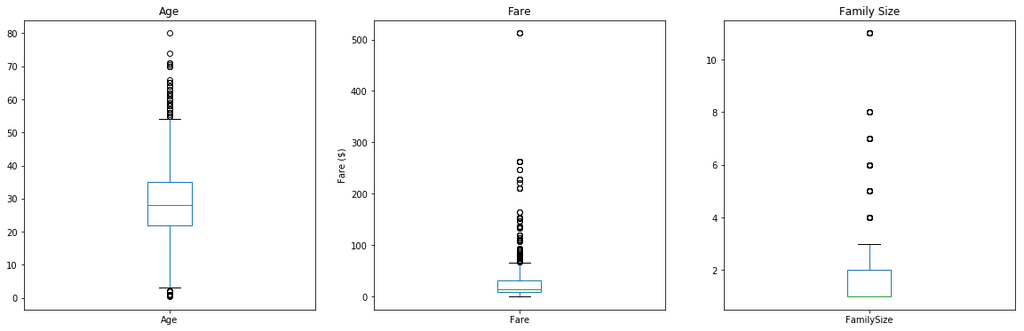

```python
fig = plt.figure(figsize=(20,6))

fig.add_subplot(131)
df.Age.plot(kind='box',title='Age')

fig.add_subplot(132)
plt.ylabel('Fare ($)')
df.Fare.plot(kind='box',title='Fare')

fig.add_subplot(133)
df.FamilySize.plot(kind='box',title='Family Size')
```

```
Text(0.5,1,'Distribution of Survivors by Family Size')
```

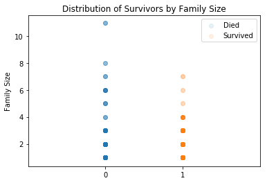

```python
plt.scatter(df.Survived[mask_died],df.FamilySize[mask_died],alpha=0.1,label='Died')
plt.scatter(df.Survived[mask_survived],df.FamilySize[mask_survived],alpha=0.1,label='Survived')
plt.ylabel('Family Size')
plt.legend()
plt.xticks([0,1])
plt.xlim(-1,2)
plt.title('Distribution of Survivors by Family Size')
# plt.tick_params(size=10)
```